# Bacterial community assessment of drinking water and downstream distribution systems in highland localities of Ecuador Main Code Resources

- QGIS information [link](https://github.com/EcuadorianMP/Drinking-Water-Microbiome/tree/main/QGIS)
- R Data analysis [link](https://github.com/EcuadorianMP/Drinking-Water-Microbiome/tree/main/R)
- Kronas plots [link](https://github.com/EcuadorianMP/Drinking-Water-Microbiome/tree/main/R/plots/Supplmental/Kronas)

## Abstract

Bacterial communities in drinking water provide a gauge to measure quality and confer insights into public health. In contrast to urban systems, water treatment in rural areas is not adequately monitored and could become a health risk. We performed 16S rRNA amplicon sequencing to analyze the microbiome present in the water treatment plants (WTP) at two rural agricultural communities, one city, and the downstream water for human consumption in schools and reservoirs in the Andean highlands of Ecuador. We tested the effect of water treatment on the diversity and composition of bacterial communities. A set of physicochemical variables in the sampled water was evaluated and correlated with the structure of the observed bacterial communities. Predominant bacteria in the analyzed communities belonged to Proteobacteria and Actinobacteria. The Sphingobium genus, a chlorine resistance group, was particularly abundant. Of health concern in drinking water reservoirs were Fusobacteriaceae, Lachnospiraceae, and Ruminococcaceae; these families are associated with human and poultry fecal contamination. We propose the latter families as relevant biomarkers for establishing local standards for the monitoring of potable water systems in agricultural lands in highland Ecuador. Our assessment of bacterial community composition in water systems in the Ecuadorian highlands provides a technical background to inform management decisions.

# Main figures

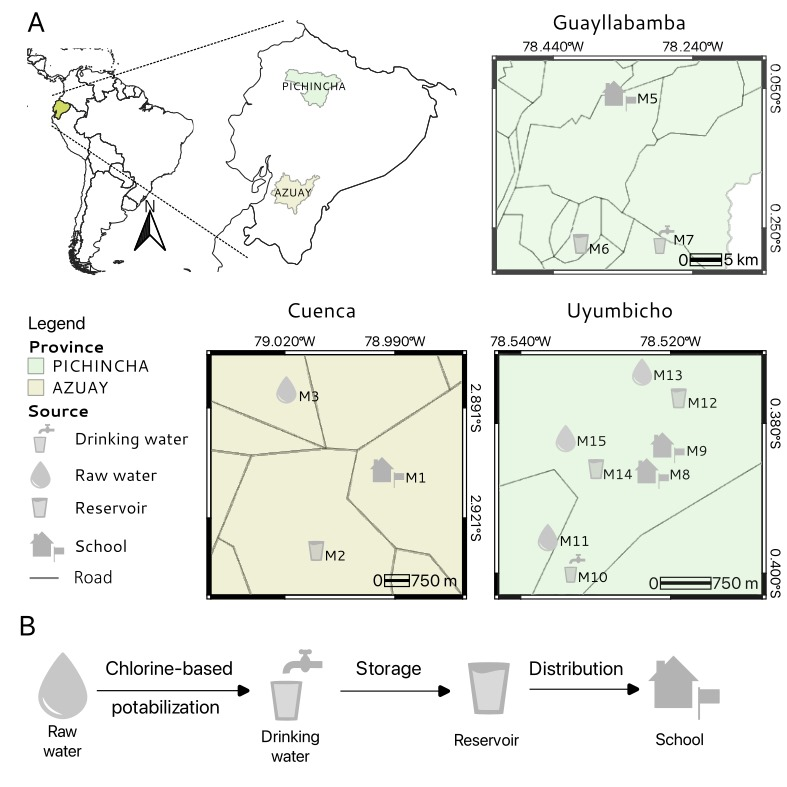

Figure 1. (A) Sample locations, sample codification, and sample sources. (B) Sampling design along the drinking water distribution system from raw water sources to tap water in schools.

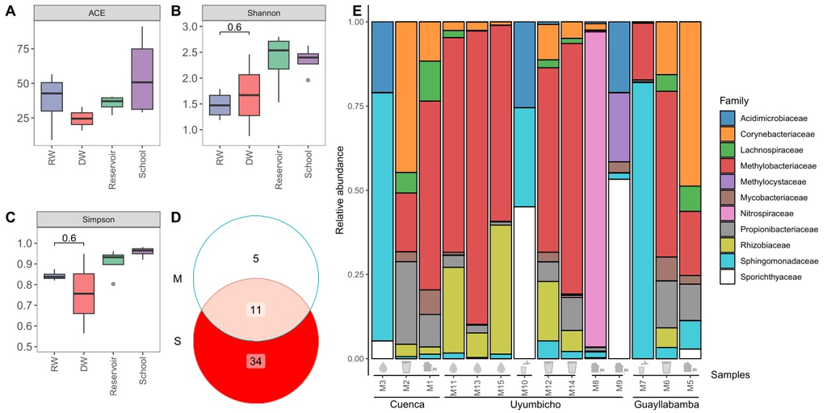

Figure 2. Structure and diversity of bacterial communities across water samples before and after treatment. (A) ACE, (B) Shannon, and (C) Simpson alpha diversity indexes by sample. All Wilcoxon non-parametric contrast tests between samples were significant, except for the contrast between RW and DW for the Shannon and Simpson indexes (p>=0.6). (D) Venn diagram of the assigned families between the Silva-S and MiDAS-M databases. (E) Relative abundance by sample of the eleven most abundant families, with the taxonomic classification based on the Silva database.

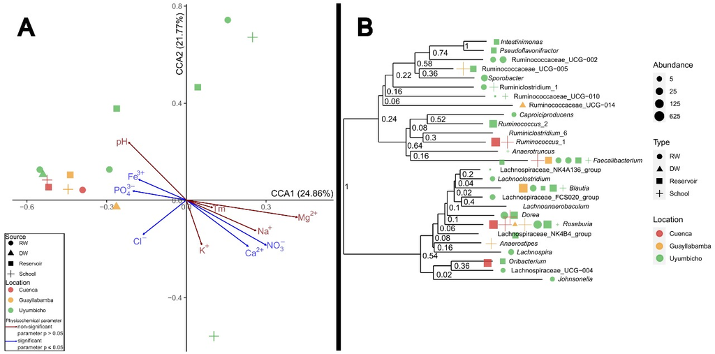

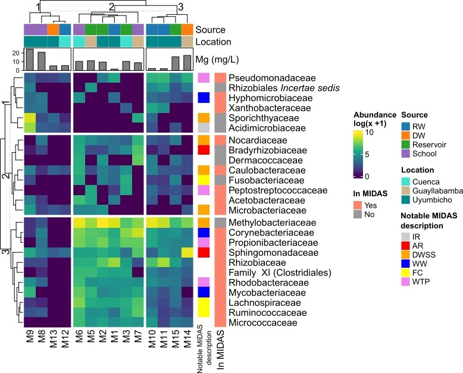

Figure 4. Abundance heatmap of the first 25th most abundant families. The OTUs’ abundance was log-transformed and clustered according to their occurrence by the UPGMA hierarchical clustering. Annotations and color scales correspond to metabolic characteristics found in the literature and their presence in the MiDAS database